# Aviation Accidents Overview - 2008 to 2021

### *Dataset for this report is retrieved through the Data Services of ICAO (International Civil Aviation Organization). This dataset includes data about official accidents (should not be mistaken with incidents) between Jan 2008 and March 2021 happened around the world.*

Data: https://www.icao.int/safety/iStars/Pages/API-Data-Service-new.aspx

### Import libraries

```python
import numpy as np
import pandas as pd
import matplotlib.pyplot as plt
```

### Read .csv file and retrieve data

```python
df = pd.read_csv('aviation_crashes_2008_2021.csv')
df.info()
```

```
<class 'pandas.core.frame.DataFrame'>
RangeIndex: 1284 entries, 0 to 1283
Data columns (total 25 columns):
 #   Column               Non-Null Count  Dtype
---  ------               --------------  -----
 0   Date                 1284 non-null   object
 1   StateOfOccurrence    1263 non-null   object
 2   Location             1148 non-null   object
 3   Model                1284 non-null   object
 4   Registration         1284 non-null   object
 5   Operator             1137 non-null   object
 6   StateOfOperator      1137 non-null   object
 7   StateOfRegistry      1282 non-null   object
 8   FlightPhase          1043 non-null   object
 9   Class                1284 non-null   object
```

[output cut: 17 more lines]

##### Take a look at the first rows of the dataset to clearly understand the structure.

```python
df.head()
```

|  | Date | StateOfOccurrence | Location | Model | Registration | Operator | StateOfOperator | StateOfRegistry | FlightPhase | Class | ... | TypeDesignator | Airplane | Engines | EngineType | Official | OccCats | Risk | Year | Country | AircraftType |
| --- | --- | --- | --- | --- | --- | --- | --- | --- | --- | --- | --- | --- | --- | --- | --- | --- | --- | --- | --- | --- | --- |
| 0 | "2014-07-17T00:00:00.000Z" | UKR | Grabovo | Boeing 777 | 9M-MRD | Malaysia Malaysian Airlines System | MYS | MYS | En route | Accident | ... | B37M | True | 2 | Jet | 1 | ["SEC"] | OTH | 2014 | Ukraine | Boeing 737 MAX 7 |
| 1 | "2014-03-08T00:00:00.000Z" | MAL | Unknown | Boeing 777 | 9M-MRO | Malaysia Malaysian Airlines System | MYS | MYS | Unknown | Accident | ... | B37M | True | 2 | Jet | 1 | ["UNK"] | UNK | 2014 | Malaysia | Boeing 737 MAX 7 |
| 2 | "2015-10-31T00:00:00.000Z" | EGY | near Sharm el Sheikh | Airbus A321 | EI-ETJ | Metrojet | RUS | IRL | En route | Accident | ... | A321 | True | 2 | Jet | 1 | ["SEC","UNK"] | SEC | 2015 | Egypt | Airbus A321 |
| 3 | "2018-10-29T00:00:00.000Z" | IDN | 15 km N off Tanjung Bungin | Boeing 737 MAX | PK-LQP | Lion Air | IDN | IDN | En route | Accident | ... | B37M | True | 2 | Jet | 1 | ["LOC-I","SCF-NP"] | LOC-I | 2018 | Indonesia | Boeing 737 MAX 7 |
| 4 | "2012-06-03T00:00:00.000Z" | NGA | IJU ISHAGA, LAGOS | MD 83 | 5N-RAM | Nepal | NGA | NGA | Approach | Accident | ... | L8 | True | 1 | Piston | 1 | [] | UNK | 2012 | Nigeria | MD 83 |

5 rows × 25 columns

#### For specific statistics in terms of time, converting the values in column "Date" to datetime format is required.

```python
df["Date"]= pd.to_datetime(df["Date"], format="\"%Y-%m-%dT%H:%M:%S.%fZ\"")
df.head()
```

|  | Date | StateOfOccurrence | Location | Model | Registration | Operator | StateOfOperator | StateOfRegistry | FlightPhase | Class | ... | TypeDesignator | Airplane | Engines | EngineType | Official | OccCats | Risk | Year | Country | AircraftType |
| --- | --- | --- | --- | --- | --- | --- | --- | --- | --- | --- | --- | --- | --- | --- | --- | --- | --- | --- | --- | --- | --- |
| 0 | 2014-07-17 | UKR | Grabovo | Boeing 777 | 9M-MRD | Malaysia Malaysian Airlines System | MYS | MYS | En route | Accident | ... | B37M | True | 2 | Jet | 1 | ["SEC"] | OTH | 2014 | Ukraine | Boeing 737 MAX 7 |
| 1 | 2014-03-08 | MAL | Unknown | Boeing 777 | 9M-MRO | Malaysia Malaysian Airlines System | MYS | MYS | Unknown | Accident | ... | B37M | True | 2 | Jet | 1 | ["UNK"] | UNK | 2014 | Malaysia | Boeing 737 MAX 7 |
| 2 | 2015-10-31 | EGY | near Sharm el Sheikh | Airbus A321 | EI-ETJ | Metrojet | RUS | IRL | En route | Accident | ... | A321 | True | 2 | Jet | 1 | ["SEC","UNK"] | SEC | 2015 | Egypt | Airbus A321 |
| 3 | 2018-10-29 | IDN | 15 km N off Tanjung Bungin | Boeing 737 MAX | PK-LQP | Lion Air | IDN | IDN | En route | Accident | ... | B37M | True | 2 | Jet | 1 | ["LOC-I","SCF-NP"] | LOC-I | 2018 | Indonesia | Boeing 737 MAX 7 |
| 4 | 2012-06-03 | NGA | IJU ISHAGA, LAGOS | MD 83 | 5N-RAM | Nepal | NGA | NGA | Approach | Accident | ... | L8 | True | 1 | Piston | 1 | [] | UNK | 2012 | Nigeria | MD 83 |

5 rows × 25 columns

##### For this dataset, the Injury level of the accidents will only be classified into 2 types: Fatal (number of Fatalities > 0) and Non-Fatal (number of Fatalities = 0)

```python
df.loc[df["Fatalities"].isna(), ["Fatalities"]] = 0
```

```python
df.loc[df["Fatalities"] > 0, ["InjuryLevel"]] = "Fatal"
df.loc[df["Fatalities"] == 0, ["InjuryLevel"]] = "Non-Fatal"
```

##### Plot out the ratio to generally see the distribution of the 2 types of Injury levels among all Aviation Accidents

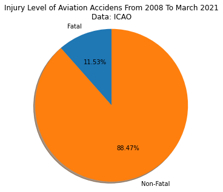

```python
injury_levels = df["InjuryLevel"].unique()
injury_levels_percentages = []
for level in injury_levels:
    injury_levels_percentages.append(df[df["InjuryLevel"] == level]["InjuryLevel"].count() / df["InjuryLevel"].count())

plt.rcParams.update({'font.size' : 10})

fig, ax = plt.subplots(figsize = (5, 5))
ax.set_title("Injury Level of Aviation Accidens From 2008 To March 2021\nData: ICAO")
ax.pie(injury_levels_percentages, labels=injury_levels, autopct='%1.2f%%',
       shadow=True, startangle=90)
ax.axis('equal')
plt.show()
```

### Observation 1: Clearly, the number of Non-Fatal accidents is much more than Fatal accidents. Total number of Fatal accidents make up to no more than 12% of the whole dataset.

#### This part will explore about the phases of flights where the accidents happened, target to point out the phases when the accidents are more likely to happen.

```python
df["FlightPhase"].unique()
```

```
array(['En route', 'Unknown', 'Approach', 'Landing', 'Take-off', nan,
       'Initial Climb', 'Standing', 'Taxi', 'Manoeuvring'], dtype=object)
```

```python
def add_value_labels(ax, spacing=5):
    for rect in ax.patches:
        y_value = rect.get_height()
        x_value = rect.get_x() + rect.get_width() / 2
        space = spacing
        va = 'bottom'
        label = "{:d}".format(y_value)

        ax.annotate(
            label,
            (x_value, y_value),
            xytext=(0, space),
            textcoords="offset points",
            ha='center',
            va=va)
```

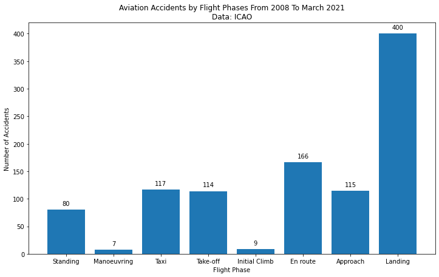

```python
flight_phases = ['Standing', 'Manoeuvring', 'Taxi', 'Take-off', 'Initial Climb', 'En route', 'Approach', 'Landing']
flight_phases_count = []

for flight_phase in flight_phases:
    flight_phases_count.append(df[df["FlightPhase"] == flight_phase]["FlightPhase"].count())

fig, ax = plt.subplots(figsize = (12, 7))
ax.set_title("Aviation Accidents by Flight Phases From 2008 To March 2021\nData: ICAO")
ax.bar(flight_phases, flight_phases_count)
plt.xlabel('Flight Phase')
plt.ylabel('Number of Accidents')
add_value_labels(ax, 5)
plt.show()
```

### Observation 2: Accidents tend to occur during the landing process of flights, accounting for more than double of the cases compared to other phases of flight. Generally, the phases of Manoeuvring and Initial Climb seem to be much safer than the others, accounting for only a few cases.

#### This part points out some statistics about the number of accidents happened on different locations. In this part, locations are classified to not smaller than Country unit.

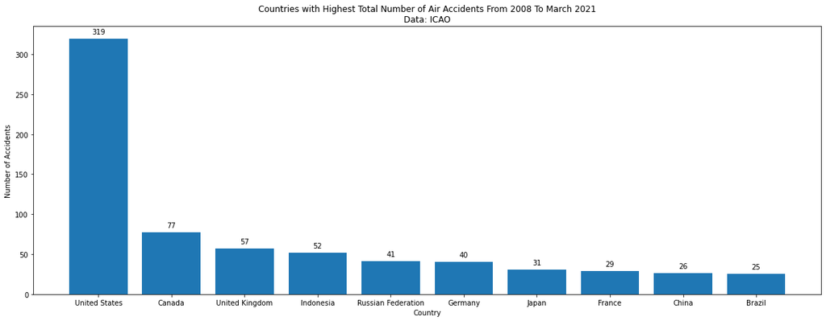

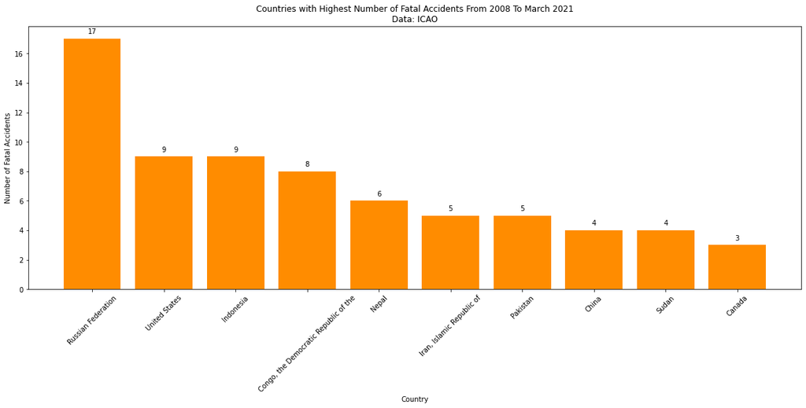

```python
df["Country"].unique()
countries_count = []
for country in df["Country"].unique():
    obj = {
        "Country": country,
        "Number of Crashes": df[df["Country"] == country]["Country"].count(),
        "Number of Fatal Accidents": df[(df["Country"] == country) & (df["InjuryLevel"] == "Fatal")]["Country"].count()
    }
    countries_count.append(obj)

countries_count.sort(key=lambda x: x["Number of Crashes"], reverse=True)

countries = []
count = []
for i in range(10):
    countries.append(countries_count[i]["Country"])
    count.append(countries_count[i]["Number of Crashes"])

fig, ax = plt.subplots(figsize = (20, 7))
ax.set_title("Countries with Highest Total Number of Air Accidents From 2008 To March 2021\nData: ICAO")
ax.bar(countries, count)
add_value_labels(ax, 5)
plt.xlabel('Country')
plt.ylabel('Number of Accidents')
plt.show()

countries_count.sort(key=lambda x: x["Number of Fatal Accidents"], reverse=True)
countries = []
count = []
for i in range(10):
    countries.append(countries_count[i]["Country"])
    count.append(countries_count[i]["Number of Fatal Accidents"])

fig, ax = plt.subplots(figsize = (20, 7))
ax.set_title("Countries with Highest Number of Fatal Accidents From 2008 To March 2021\nData: ICAO")
ax.bar(countries, count, color="darkorange")
plt.xlabel('Country')
plt.ylabel('Number of Fatal Accidents')
plt.xticks(countries, rotation=45)
add_value_labels(ax, 5)
plt.show()
```

### Observation 3: A very large number of accidents occurred on the land of the United States, many times more than the other countries. This can be explained by the fact that the number of traffics on US airspace is always the highest all over the world. In contrast to that, only 9 over 319 accidents happened on the States are fatal. The highest number of fatal accidents is of Russian Federation, accounting up to 17 cases during 2008 and March 2021.

#### This part continues to statisticize about the total number of people died (death toll) during the accidents for different country and different time periods

##### Plot out some of the most fatal aviation accidents between 2008 and 2021

```python
df.nlargest(10, "Fatalities")
```

|  | Date | StateOfOccurrence | Location | Model | Registration | Operator | StateOfOperator | StateOfRegistry | FlightPhase | Class | ... | TypeDesignator | Airplane | Engines | EngineType | Official | OccCats | Risk | Year | Country | AircraftType |
| --- | --- | --- | --- | --- | --- | --- | --- | --- | --- | --- | --- | --- | --- | --- | --- | --- | --- | --- | --- | --- | --- |
| 0 | 2014-07-17 | UKR | Grabovo | Boeing 777 | 9M-MRD | Malaysia Malaysian Airlines System | MYS | MYS | En route | Accident | ... | B37M | True | 2 | Jet | 1 | ["SEC"] | OTH | 2014 | Ukraine | Boeing 737 MAX 7 |
| 1 | 2014-03-08 | MAL | Unknown | Boeing 777 | 9M-MRO | Malaysia Malaysian Airlines System | MYS | MYS | Unknown | Accident | ... | B37M | True | 2 | Jet | 1 | ["UNK"] | UNK | 2014 | Malaysia | Boeing 737 MAX 7 |
| 1193 | 2009-06-01 | NaN | A proximité du point TASIL | AIRBUS A330 200 | F-GZCP | France Air France | FRA | FRA | En route | Accident | ... | BE20 | True | 2 | Turboprop | TRUE | ["ICE","LOC-I"] | LOC-I | 2009 | United Kingdom | NaN |
| 2 | 2015-10-31 | EGY | near Sharm el Sheikh | Airbus A321 | EI-ETJ | Metrojet | RUS | IRL | En route | Accident | ... | A321 | True | 2 | Jet | 1 | ["SEC","UNK"] | SEC | 2015 | Egypt | Airbus A321 |
| 3 | 2018-10-29 | IDN | 15 km N off Tanjung Bungin | Boeing 737 MAX | PK-LQP | Lion Air | IDN | IDN | En route | Accident | ... | B37M | True | 2 | Jet | 1 | ["LOC-I","SCF-NP"] | LOC-I | 2018 | Indonesia | Boeing 737 MAX 7 |
| 1216 | 2009-07-15 | IRN | Janat-Abad | TUPOLEVTU-154M/TU-164 TU154 | EP-CPG | Iran, Islamic Republic Of Caspian Airlines | IRN | IRN | En route | Accident | ... | T154 | True | 3 | Jet | TRUE | ["SCF-PP","F-NI"] | CFIT | 2009 | Iran, Islamic Republic of | NaN |
| 4 | 2012-06-03 | NGA | IJU ISHAGA, LAGOS | MD 83 | 5N-RAM | Nepal | NGA | NGA | Approach | Accident | ... | L8 | True | 1 | Piston | 1 | [] | UNK | 2012 | Nigeria | MD 83 |
| 5 | 2014-12-28 | IDN | Over Java Sea (Karimata strait) approximately ... | Airbus A320 | PK-AXC | INDONESIA AIRASIA, PT. | IDN | IDN | En route | Accident | ... | A320 | True | 2 | Jet | 1 | ["SCF-NP","LOC-I"] | LOC-I | 2014 | Indonesia | Airbus A320 |
| 6 | 2010-05-22 | IND | Mangalore a/p | BOEING 737 | VT-AXV | India Air India | IND | IND | Landing | Accident | ... | B37M | True | 2 | Jet | 1 | ["F-POST","RE"] | RS | 2010 | India | Boeing 737 MAX 7 |
| 7 | 2019-03-10 | ETH | 50 km ESE of Addis Ababa-Bole Airport (ADD) | Boeing 737 MAX 8 | ET-AVJ | Ethiopian Airlines | ETH | ETH | En route | Accident | ... | B37M | True | 2 | Jet | 1 | ["LOC-I","SCF-NP"] | SCF-NP | 2019 | Ethiopia | Boeing 737 MAX 7 |

10 rows × 25 columns

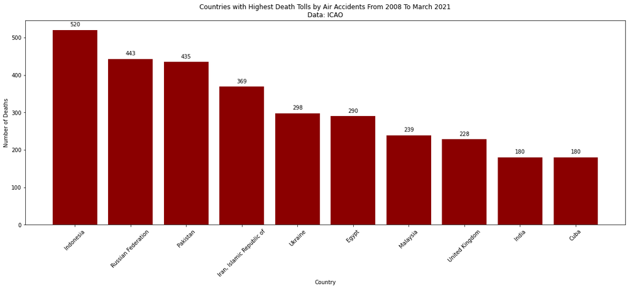

```python
countries_by_death_tolls = []

for country in df["Country"].unique():
    obj = {
        "Country": country,
        "Total death tolls": df[(df["Country"] == country) & (df["Fatalities"] > 0)]["Fatalities"].sum(axis = 0),
    }
    countries_by_death_tolls.append(obj)

countries_by_death_tolls.sort(key=lambda x: x["Total death tolls"], reverse=True)

countries = []
count = []
for i in range(10):
    countries.append(countries_by_death_tolls[i]["Country"])
    count.append(int(countries_by_death_tolls[i]["Total death tolls"]))

fig, ax = plt.subplots(figsize = (20, 7))
ax.set_title("Countries with Highest Death Tolls by Air Accidents From 2008 To March 2021\nData: ICAO")
ax.bar(countries, count, color="darkred")
plt.xlabel('Country')
plt.ylabel('Number of Deaths')
plt.xticks(countries, rotation=45)
add_value_labels(ax, 5)
plt.show()
```

#### Indonesia and Russian Federation along with most number of fatal accidents still hold the top places for most number of deaths caused by aviation accidents.

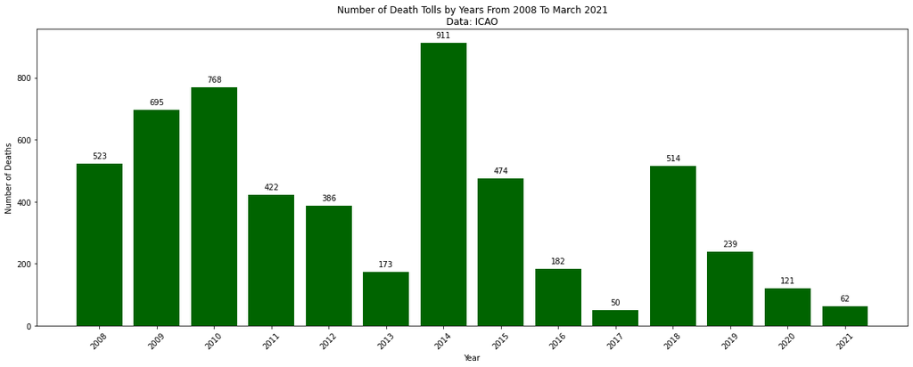

```python
years = [i for i in range(2008, 2022)]

death_counts = []

for year in years:
    death_counts.append(int(df[(df["Year"] == year) & (df["Fatalities"] > 0)]["Fatalities"].sum(axis = 0)))

fig, ax = plt.subplots(figsize = (20, 7))
ax.set_title("Number of Death Tolls by Years From 2008 To March 2021\nData: ICAO")
ax.bar(years, death_counts, color="darkgreen")
plt.xticks(years, rotation=45)
plt.xlabel('Year')
plt.ylabel('Number of Deaths')
add_value_labels(ax, 5)
plt.show()
```

#### From the above chart, it is not enough to point out the change rules of aviation safety through the years. The number of people died from accidents tend to change unstably through the years.

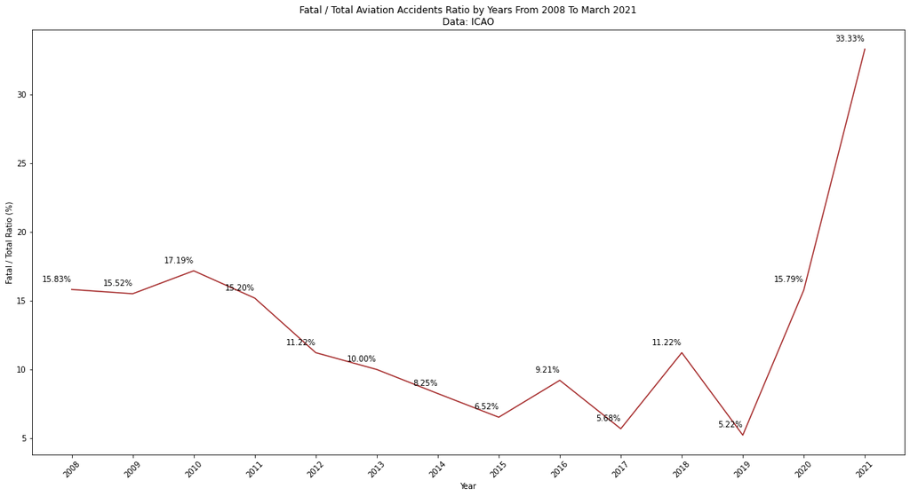

```python
death_case_ratio = []

for year in years:
    death_case_ratio.append(100 * df[(df["Year"] == year) & (df["Fatalities"] > 0)]["Year"].count() / df[df["Year"] == year]["Year"].count())

fig, ax = plt.subplots(figsize = (20, 10))
ax.set_title("Fatal / Total Aviation Accidents Ratio by Years From 2008 To March 2021\nData: ICAO")
ax.plot(years, death_case_ratio, color="brown")
plt.xticks(years, rotation=45)
plt.xlabel('Year')
plt.ylabel('Fatal / Total Ratio (%)')
for year, death_case_ratio in zip(years, death_case_ratio):
    ax.annotate('{:.2f}%'.format(death_case_ratio), xy=(year,death_case_ratio), xytext=(0, 10), ha='right',
                textcoords='offset points')

plt.show()
```

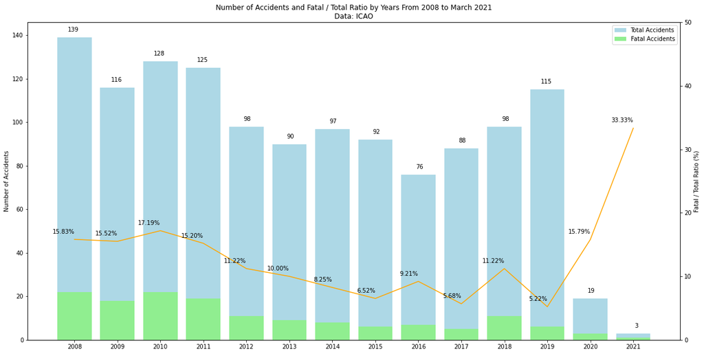

```python
cases_by_years = []
death_case_ratio = []
fatal_case_by_years = []

for year in years:
    cases_by_years.append(df[df["Year"] == year]["Year"].count())
    death_case_ratio.append(100 * df[(df["Year"] == year) & (df["Fatalities"] > 0)]["Year"].count() / df[df["Year"] == year]["Year"].count())
    fatal_case_by_years.append(df[(df["Year"] == year) & (df["Fatalities"] > 0)]["Year"].count())

plt.figure(figsize = (20, 10))
plt.title("Number of Accidents and Fatal / Total Ratio by Years From 2008 to March 2021\nData: ICAO")
plt.bar(years, cases_by_years, color='lightblue')
plt.bar(years, fatal_case_by_years, color='lightgreen')
plt.ylabel('Number of Accidents')
plt.legend(['Total Accidents', 'Fatal Accidents'])
plt.xticks(years)
for year, cases_by_year in zip(years, cases_by_years):
    plt.annotate('{}'.format(cases_by_year), xy=(year,cases_by_year), xytext=(8, 10), ha='right',
                textcoords='offset points')

x = years
axes2 = plt.twinx()
axes2.plot(years, death_case_ratio, color='orange', label='Sine')
axes2.set_ylabel('Fatal / Total Ratio (%)')
for year, death_case_ratio in zip(years, death_case_ratio):
    axes2.annotate('{:.2f}%'.format(death_case_ratio), xy=(year,death_case_ratio), xytext=(0, 10), ha='right',
                textcoords='offset points')
axes2.set_ylim(0, 50)

plt.show()
```

#### Plotting both the number of accidents and fatal / total ratio (ratio between number of fatal accidents among all accidents) and point out that the ratio tends to decreased through the years. It is clear that except 2010 and 2018, the number of fatal accidents tend to decreased through the years. The ratio increased at some points but that can be explained by the fact that the number of accidents in those years are different (the cases of 2020 and 2021).

### Observation 4: It is not enough to fully assume that Civil Aviation in general has become progressively safer throughout the years 2008 to 2021, but in general, the number of accidents and especially the number of fatal accidents tend to decrease year by year.

#### This part gives some statistics about aircraft families of 2 largest aircraft manufacturers: Airbus and Boeing, in terms of the number of accidents occured and the number of fatal accidents occured.

```python
aircraft_families_code = ['707', '717', '727', '737', '747', '757', '767', '777', '787',
                          'A300', '300', '310', '320', '321', '318', '319', '330', '340', '350', '380']
aircraft_families_name = ['Boeing 707', 'Boeing 717', 'Boeing 727', 'Boeing 737', 'Boeing 747', 'Boeing 757', 'Boeing 767', 'Boeing 777', 'Boeing 787',
                          'Airbus A300', 'Airbus A300',
                          'Airbus A310', 'Airbus A320', 'Airbus A321', 'Airbus A318', 'Airbus A319',
                          'Airbus A330', 'Airbus A340', 'Airbus A350', 'Airbus A380']
families = []
added = False

for row in df.iterrows():
    added = False
    get_model = row[1][3]
    for i, code in enumerate(aircraft_families_code):
        if get_model.find(code) != -1:
            families.append(aircraft_families_name[i])
            added = True
            break
    if (not added):
        families.append("Other")

df["Aircraft Family"] = families
```

```python
accidents_count_by_types = dict()
fatal_count_by_types = dict()
statistic_count = dict()

obj_list = []

for family in df["Aircraft Family"].unique():
    if (family != 'Other'):
        obj = {
            "Family": family,
            "Accidents": df[df["Aircraft Family"] == family]["Aircraft Family"].count(),
            "Fatal": df[(df["Aircraft Family"] == family) & (df["Fatalities"] > 0)]["Aircraft Family"].count()
        }
        accidents_count_by_types[family] = df[df["Aircraft Family"] == family]["Aircraft Family"].count()
        fatal_count_by_types[family] = df[(df["Aircraft Family"] == family) & (df["Fatalities"] > 0)]["Aircraft Family"].count()
        obj_list.append(obj)

obj_list.sort(key=lambda x: x["Accidents"], reverse=True)

for obj in obj_list:
    if (obj["Family"] != 'Other'):
        family = obj["Family"]
        statistic_count[family] = [accidents_count_by_types[family], fatal_count_by_types[family]]

df_tmp = pd.DataFrame.from_dict(statistic_count, orient='index', columns = ['Total Accidents', 'Fatal Accidents'])
```

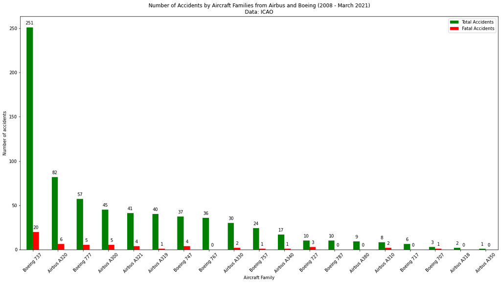

```python
ax = df_tmp.plot(kind='bar', figsize=(20, 10), color=["green", "red"])
plt.title("Number of Accidents by Aircraft Families from Airbus and Boeing (2008 - March 2021)\nData: ICAO")
plt.legend(['Total Accidents', 'Fatal Accidents'])
add_value_labels(ax, 5)
plt.xticks(rotation=45)
plt.ylabel("Number of accidents")
plt.xlabel("Aircraft Family")
plt.show()
```

### Observation 5: Clearly, Boeing 737 seems to be the most problematic aircraft family in this generation of Civil Aviation. Despite the fact that the number of flights operated by Boeing 737 can be much higher than other families, the number is still "huge". Generally, Airbus seems to be a safer choice.

#### The final part of the report statisticize information about the distribution of accidents on different months, days and dates.

```python
time_df = pd.DataFrame()
time_df['Month'] = pd.DatetimeIndex(df['Date']).month
time_df['Day'] = pd.DatetimeIndex(df['Date']).day
time_df['Merged'] = df['Date'].dt.strftime("%d/%m")

months = []
days = []
merge_days = time_df['Merged'].unique()
merge_days_obj = []

for i in range(1, 13):
    obj = {
        "Month": i,
        "Accidents": df[pd.DatetimeIndex(df['Date']).month == i]["Date"].count(),
        "Fatal": df[(pd.DatetimeIndex(df['Date']).month == i) & (df["Fatalities"] > 0)]["Date"].count()
    }
    months.append(obj)

for i in range(1, 32):
    obj = {
        "Day": i,
        "Accidents": df[pd.DatetimeIndex(df['Date']).day == i]["Date"].count(),
        "Fatal": df[(pd.DatetimeIndex(df['Date']).day == i) & (df["Fatalities"] > 0)]["Date"].count()
    }
    days.append(obj)

for merge_day in merge_days:
    obj = {
        "Date": merge_day,
        "Accidents": df[df['Date'].dt.strftime("%d/%m") == merge_day]["Date"].count(),
        "Fatal": df[(df['Date'].dt.strftime("%d/%m") == merge_day) & (df["Fatalities"] > 0)]["Date"].count()
    }
    merge_days_obj.append(obj)

days.sort(key=lambda x: x["Accidents"], reverse=True)
merge_days_obj.sort(key=lambda x: x["Accidents"], reverse=True)
```

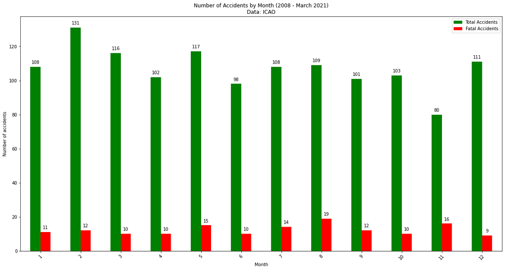

```python
month_dict = dict()
for i in range(1, 13):
    month_dict[i] = [months[i - 1]["Accidents"], months[i - 1]["Fatal"]]

df_month = pd.DataFrame.from_dict(month_dict, orient='index', columns = ['Total Accidents', 'Fatal Accidents'])

ax = df_month.plot(kind='bar', figsize=(20, 10), color=["green", "red"])
plt.title("Number of Accidents by Month (2008 - March 2021)\nData: ICAO")
plt.legend(['Total Accidents', 'Fatal Accidents'])
add_value_labels(ax, 5)
plt.xticks(rotation=45)
plt.ylabel("Number of accidents")
plt.xlabel("Month")
```

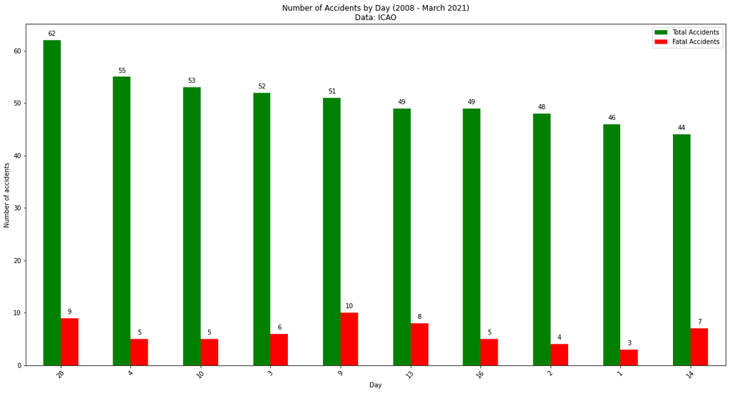

```python
day_dict = dict()
for i in range(0, 10):
    get_day = days[i]["Day"]
    get_obj = None
    for i in range(len(days)):
        if (days[i]["Day"] == get_day):
            get_obj = days[i]
            break
    day_dict[get_day] = [get_obj["Accidents"], get_obj["Fatal"]]

df_day = pd.DataFrame.from_dict(day_dict, orient='index', columns = ['Total Accidents', 'Fatal Accidents'])

ax = df_day.plot(kind='bar', figsize=(20, 10), color=["green", "red"])
plt.title("Number of Accidents by Day (2008 - March 2021)\nData: ICAO")
plt.legend(['Total Accidents', 'Fatal Accidents'])
add_value_labels(ax, 5)
plt.xticks(rotation=45)
plt.ylabel("Number of accidents")
plt.xlabel("Day")
```

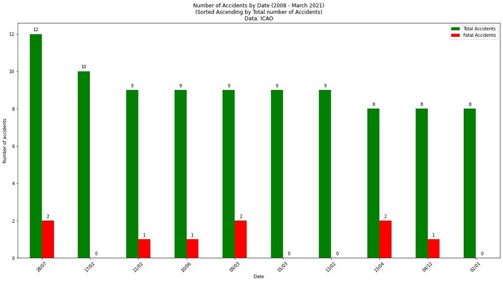

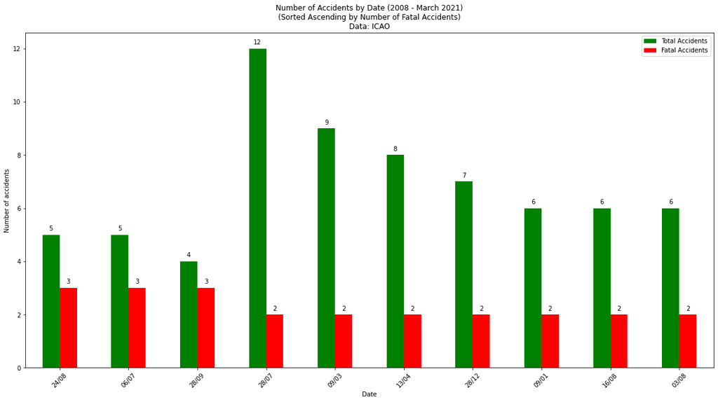

```python
day_month_dict = dict()
for i in range(0, 10):
    get_date = merge_days_obj[i]["Date"]
    get_obj = None
    for i in range(len(merge_days_obj)):
        if (merge_days_obj[i]["Date"] == get_date):
            get_obj = merge_days_obj[i]
            break
    day_month_dict[get_date] = [get_obj["Accidents"], get_obj["Fatal"]]

df_day_month = pd.DataFrame.from_dict(day_month_dict, orient='index', columns = ['Total Accidents', 'Fatal Accidents'])

ax = df_day_month.plot(kind='bar', figsize=(20, 10), color=["green", "red"])
plt.title("Number of Accidents by Date (2008 - March 2021)\n(Sorted Ascending by Total number of Accidents)\nData: ICAO")
plt.legend(['Total Accidents', 'Fatal Accidents'])
add_value_labels(ax, 5)
plt.xticks(rotation=45)
plt.ylabel("Number of accidents")
plt.xlabel("Date")

merge_days_obj.sort(key=lambda x: x["Fatal"], reverse=True)
day_month_dict = dict()
for i in range(0, 10):
    get_date = merge_days_obj[i]["Date"]
    get_obj = None
    for i in range(len(merge_days_obj)):
        if (merge_days_obj[i]["Date"] == get_date):
            get_obj = merge_days_obj[i]
            break
    day_month_dict[get_date] = [get_obj["Accidents"], get_obj["Fatal"]]

df_day_month = pd.DataFrame.from_dict(day_month_dict, orient='index', columns = ['Total Accidents', 'Fatal Accidents'])

ax = df_day_month.plot(kind='bar', figsize=(20, 10), color=["green", "red"])
plt.title("Number of Accidents by Date (2008 - March 2021)\n(Sorted Ascending by Number of Fatal Accidents)\nData: ICAO")
plt.legend(['Total Accidents', 'Fatal Accidents'])
add_value_labels(ax, 5)
plt.xticks(rotation=45)
plt.ylabel("Number of accidents")
plt.xlabel("Date")
```